# Risk Factor Analysis

## Outcome Variable

**Outcome Variable:** pers_wast

## Predictor Variables

**Intervention Variable:** exclfeed36

**Adjustment Set:**

- arm
- sex
- W_mage
- meducyrs
- feducyrs
- hhwealth_quart
- hfoodsec
- W_mhtcm
- vagbrth
- W_birthwt
- W_birthlen
- W_nrooms
- W_nchldlt5
- month
- brthmon
- W_parity
- impfloor
- impsan
- safeh20
- delta_W_mage
- delta_meducyrs
- delta_feducyrs
- delta_hhwealth_quart
- delta_hfoodsec
- delta_W_mhtcm
- delta_vagbrth
- delta_W_birthwt
- delta_W_birthlen
- delta_W_nrooms
- delta_W_nchldlt5
- delta_month
- delta_brthmon
- delta_W_parity
- delta_impfloor
- delta_impsan
- delta_safeh20

## Stratifying Variables

The analysis was stratified on these variable(s):

- agecat
- studyid
- country

## Data Summary

| agecat | studyid | country | exclfeed36 | pers_wast | n_cell | n |
| --- | --- | --- | --- | --- | --- | --- |
| 0-24 months | ki0047075b-MAL-ED | BANGLADESH | 1 | 0 | 61 | 247 |
| 0-24 months | ki0047075b-MAL-ED | BANGLADESH | 1 | 1 | 3 | 247 |
| 0-24 months | ki0047075b-MAL-ED | BANGLADESH | 0 | 0 | 173 | 247 |
| 0-24 months | ki0047075b-MAL-ED | BANGLADESH | 0 | 1 | 10 | 247 |
| 0-24 months | ki0047075b-MAL-ED | BRAZIL | 1 | 0 | 18 | 217 |
| 0-24 months | ki0047075b-MAL-ED | BRAZIL | 1 | 1 | 0 | 217 |
| 0-24 months | ki0047075b-MAL-ED | BRAZIL | 0 | 0 | 197 | 217 |
| 0-24 months | ki0047075b-MAL-ED | BRAZIL | 0 | 1 | 2 | 217 |
| 0-24 months | ki0047075b-MAL-ED | INDIA | 1 | 0 | 7 | 241 |
| 0-24 months | ki0047075b-MAL-ED | INDIA | 1 | 1 | 0 | 241 |
| 0-24 months | ki0047075b-MAL-ED | INDIA | 0 | 0 | 213 | 241 |
| 0-24 months | ki0047075b-MAL-ED | INDIA | 0 | 1 | 21 | 241 |
| 0-24 months | ki0047075b-MAL-ED | NEPAL | 1 | 0 | 15 | 238 |
| 0-24 months | ki0047075b-MAL-ED | NEPAL | 1 | 1 | 0 | 238 |
| 0-24 months | ki0047075b-MAL-ED | NEPAL | 0 | 0 | 219 | 238 |
| 0-24 months | ki0047075b-MAL-ED | NEPAL | 0 | 1 | 4 | 238 |
| 0-24 months | ki0047075b-MAL-ED | PERU | 1 | 0 | 16 | 282 |
| 0-24 months | ki0047075b-MAL-ED | PERU | 1 | 1 | 0 | 282 |
| 0-24 months | ki0047075b-MAL-ED | PERU | 0 | 0 | 265 | 282 |
| 0-24 months | ki0047075b-MAL-ED | PERU | 0 | 1 | 1 | 282 |
| 0-24 months | ki0047075b-MAL-ED | SOUTH AFRICA | 1 | 0 | 0 | 273 |
| 0-24 months | ki0047075b-MAL-ED | SOUTH AFRICA | 1 | 1 | 0 | 273 |
| 0-24 months | ki0047075b-MAL-ED | SOUTH AFRICA | 0 | 0 | 271 | 273 |
| 0-24 months | ki0047075b-MAL-ED | SOUTH AFRICA | 0 | 1 | 2 | 273 |
| 0-24 months | ki0047075b-MAL-ED | TANZANIA, UNITED REPUBLIC OF | 1 | 0 | 1 | 253 |
| 0-24 months | ki0047075b-MAL-ED | TANZANIA, UNITED REPUBLIC OF | 1 | 1 | 0 | 253 |
| 0-24 months | ki0047075b-MAL-ED | TANZANIA, UNITED REPUBLIC OF | 0 | 0 | 252 | 253 |
| 0-24 months | ki0047075b-MAL-ED | TANZANIA, UNITED REPUBLIC OF | 0 | 1 | 0 | 253 |
| 0-24 months | ki1000108-CMC-V-BCS-2002 | INDIA | 1 | 0 | 9 | 9 |
| 0-24 months | ki1000108-CMC-V-BCS-2002 | INDIA | 1 | 1 | 0 | 9 |

[output cut: 162 more lines]

The following strata were considered:

- agecat: 0-24 months, studyid: ki0047075b-MAL-ED, country: BANGLADESH
- agecat: 0-24 months, studyid: ki0047075b-MAL-ED, country: BRAZIL
- agecat: 0-24 months, studyid: ki0047075b-MAL-ED, country: INDIA
- agecat: 0-24 months, studyid: ki0047075b-MAL-ED, country: NEPAL
- agecat: 0-24 months, studyid: ki0047075b-MAL-ED, country: PERU
- agecat: 0-24 months, studyid: ki0047075b-MAL-ED, country: SOUTH AFRICA
- agecat: 0-24 months, studyid: ki0047075b-MAL-ED, country: TANZANIA, UNITED REPUBLIC OF
- agecat: 0-24 months, studyid: ki1000108-CMC-V-BCS-2002, country: INDIA
- agecat: 0-24 months, studyid: ki1000108-IRC, country: INDIA
- agecat: 0-24 months, studyid: ki1000109-EE, country: PAKISTAN
- agecat: 0-24 months, studyid: ki1000304b-SAS-FoodSuppl, country: INDIA
- agecat: 0-24 months, studyid: ki1017093b-PROVIDE, country: BANGLADESH
- agecat: 0-24 months, studyid: ki1101329-Keneba, country: GAMBIA
- agecat: 0-24 months, studyid: ki1113344-GMS-Nepal, country: NEPAL
- agecat: 0-24 months, studyid: ki1148112-LCNI-5, country: MALAWI
- agecat: 0-24 months, studyid: kiGH5241-JiVitA-3, country: BANGLADESH
- agecat: 0-24 months, studyid: kiGH5241-JiVitA-4, country: BANGLADESH
- agecat: 0-6 months, studyid: ki0047075b-MAL-ED, country: BANGLADESH
- agecat: 0-6 months, studyid: ki0047075b-MAL-ED, country: BRAZIL
- agecat: 0-6 months, studyid: ki0047075b-MAL-ED, country: INDIA
- agecat: 0-6 months, studyid: ki0047075b-MAL-ED, country: NEPAL
- agecat: 0-6 months, studyid: ki0047075b-MAL-ED, country: PERU
- agecat: 0-6 months, studyid: ki0047075b-MAL-ED, country: SOUTH AFRICA
- agecat: 0-6 months, studyid: ki0047075b-MAL-ED, country: TANZANIA, UNITED REPUBLIC OF
- agecat: 0-6 months, studyid: ki1000108-CMC-V-BCS-2002, country: INDIA
- agecat: 0-6 months, studyid: ki1000108-IRC, country: INDIA
- agecat: 0-6 months, studyid: ki1000109-EE, country: PAKISTAN
- agecat: 0-6 months, studyid: ki1017093b-PROVIDE, country: BANGLADESH
- agecat: 0-6 months, studyid: ki1101329-Keneba, country: GAMBIA
- agecat: 0-6 months, studyid: ki1113344-GMS-Nepal, country: NEPAL
- agecat: 0-6 months, studyid: kiGH5241-JiVitA-3, country: BANGLADESH
- agecat: 6-24 months, studyid: ki0047075b-MAL-ED, country: BANGLADESH
- agecat: 6-24 months, studyid: ki0047075b-MAL-ED, country: BRAZIL
- agecat: 6-24 months, studyid: ki0047075b-MAL-ED, country: INDIA
- agecat: 6-24 months, studyid: ki0047075b-MAL-ED, country: NEPAL
- agecat: 6-24 months, studyid: ki0047075b-MAL-ED, country: PERU
- agecat: 6-24 months, studyid: ki0047075b-MAL-ED, country: SOUTH AFRICA
- agecat: 6-24 months, studyid: ki0047075b-MAL-ED, country: TANZANIA, UNITED REPUBLIC OF
- agecat: 6-24 months, studyid: ki1000108-CMC-V-BCS-2002, country: INDIA
- agecat: 6-24 months, studyid: ki1000108-IRC, country: INDIA
- agecat: 6-24 months, studyid: ki1000109-EE, country: PAKISTAN
- agecat: 6-24 months, studyid: ki1000304b-SAS-FoodSuppl, country: INDIA
- agecat: 6-24 months, studyid: ki1017093b-PROVIDE, country: BANGLADESH
- agecat: 6-24 months, studyid: ki1101329-Keneba, country: GAMBIA
- agecat: 6-24 months, studyid: ki1113344-GMS-Nepal, country: NEPAL
- agecat: 6-24 months, studyid: ki1148112-LCNI-5, country: MALAWI
- agecat: 6-24 months, studyid: kiGH5241-JiVitA-3, country: BANGLADESH
- agecat: 6-24 months, studyid: kiGH5241-JiVitA-4, country: BANGLADESH

### Dropped Strata

Some strata were dropped due to rare outcomes:

- agecat: 0-24 months, studyid: ki0047075b-MAL-ED, country: BANGLADESH
- agecat: 0-24 months, studyid: ki0047075b-MAL-ED, country: BRAZIL
- agecat: 0-24 months, studyid: ki0047075b-MAL-ED, country: INDIA
- agecat: 0-24 months, studyid: ki0047075b-MAL-ED, country: NEPAL
- agecat: 0-24 months, studyid: ki0047075b-MAL-ED, country: PERU
- agecat: 0-24 months, studyid: ki0047075b-MAL-ED, country: SOUTH AFRICA
- agecat: 0-24 months, studyid: ki0047075b-MAL-ED, country: TANZANIA, UNITED REPUBLIC OF
- agecat: 0-24 months, studyid: ki1000108-CMC-V-BCS-2002, country: INDIA
- agecat: 0-24 months, studyid: ki1000108-IRC, country: INDIA
- agecat: 0-24 months, studyid: ki1000304b-SAS-FoodSuppl, country: INDIA
- agecat: 0-24 months, studyid: ki1017093b-PROVIDE, country: BANGLADESH
- agecat: 0-24 months, studyid: ki1148112-LCNI-5, country: MALAWI
- agecat: 0-6 months, studyid: ki0047075b-MAL-ED, country: BANGLADESH
- agecat: 0-6 months, studyid: ki0047075b-MAL-ED, country: BRAZIL
- agecat: 0-6 months, studyid: ki0047075b-MAL-ED, country: INDIA
- agecat: 0-6 months, studyid: ki0047075b-MAL-ED, country: NEPAL
- agecat: 0-6 months, studyid: ki0047075b-MAL-ED, country: PERU
- agecat: 0-6 months, studyid: ki0047075b-MAL-ED, country: SOUTH AFRICA
- agecat: 0-6 months, studyid: ki0047075b-MAL-ED, country: TANZANIA, UNITED REPUBLIC OF
- agecat: 0-6 months, studyid: ki1000108-CMC-V-BCS-2002, country: INDIA
- agecat: 0-6 months, studyid: ki1000108-IRC, country: INDIA
- agecat: 0-6 months, studyid: ki1017093b-PROVIDE, country: BANGLADESH
- agecat: 0-6 months, studyid: kiGH5241-JiVitA-3, country: BANGLADESH
- agecat: 6-24 months, studyid: ki0047075b-MAL-ED, country: BANGLADESH
- agecat: 6-24 months, studyid: ki0047075b-MAL-ED, country: BRAZIL
- agecat: 6-24 months, studyid: ki0047075b-MAL-ED, country: INDIA
- agecat: 6-24 months, studyid: ki0047075b-MAL-ED, country: NEPAL
- agecat: 6-24 months, studyid: ki0047075b-MAL-ED, country: PERU
- agecat: 6-24 months, studyid: ki0047075b-MAL-ED, country: SOUTH AFRICA
- agecat: 6-24 months, studyid: ki0047075b-MAL-ED, country: TANZANIA, UNITED REPUBLIC OF
- agecat: 6-24 months, studyid: ki1000108-CMC-V-BCS-2002, country: INDIA
- agecat: 6-24 months, studyid: ki1000108-IRC, country: INDIA
- agecat: 6-24 months, studyid: ki1000304b-SAS-FoodSuppl, country: INDIA
- agecat: 6-24 months, studyid: ki1017093b-PROVIDE, country: BANGLADESH
- agecat: 6-24 months, studyid: ki1148112-LCNI-5, country: MALAWI

## Methods Detail

We’re interested in the causal parameters $E[Y_a]$ for all values of $a \in \mathcal{A}$. These parameters represent the mean outcome if, possibly contrary to fact, we intervened to set all units to have $A=a$. Under the randomization and positivity assumptions, these are identified by the statistical parameters $\psi_a=E_W[E_{Y|A,W}(Y|A=a,W)]$. In addition, we’re interested in the mean of $Y$, $E[Y]$ under no intervention (the observed mean). We will estimate these parameters by using SuperLearner to fit the relevant likelihood factors – $E_{Y|A,W}(Y|A=a,W)$ and $p(A=a|W)$, and then updating our likelihood fit using a joint TMLE.

For unadjusted analyses ($W=\{\}$), initial likelihoods were estimated using Lrnr_glm to estimate the simple $E(Y|A)$ and Lrnr_mean to estimate $p(A)$. For adjusted analyses, a small library containing Lrnr_glmnet, Lrnr_xgboost, and Lrnr_mean was used.

Having estimated these parameters, we will then use the delta method to estimate relative risks and attributable risks relative to a prespecified baseline level of $A$.

# Results Detail

## Results Plots

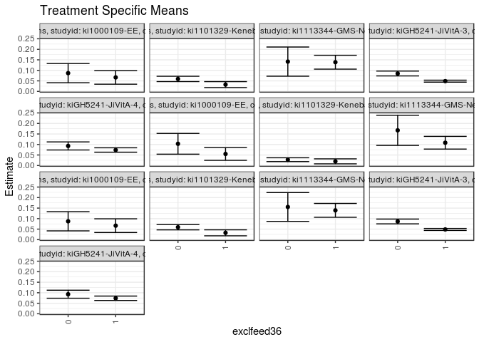

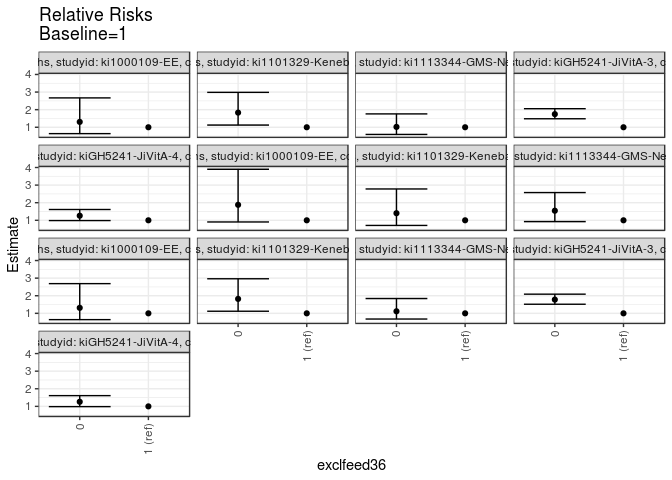

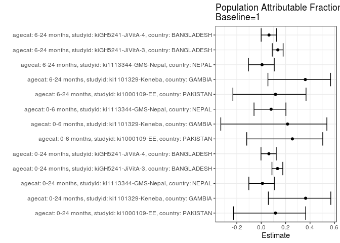

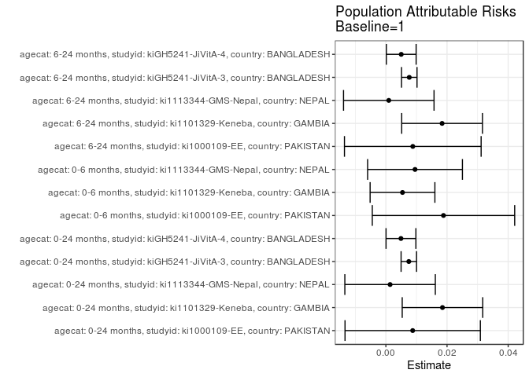

## Results Table

### Parameter: TSM

| agecat | studyid | country | intervention_level | baseline_level | estimate | ci_lower | ci_upper |
| --- | --- | --- | --- | --- | --- | --- | --- |
| 0-24 months | ki1000109-EE | PAKISTAN | 1 | NA | 0.0665011 | 0.0342149 | 0.0987873 |
| 0-24 months | ki1000109-EE | PAKISTAN | 0 | NA | 0.0867783 | 0.0411973 | 0.1323593 |
| 0-24 months | ki1101329-Keneba | GAMBIA | 1 | NA | 0.0323474 | 0.0181778 | 0.0465170 |
| 0-24 months | ki1101329-Keneba | GAMBIA | 0 | NA | 0.0592496 | 0.0465832 | 0.0719159 |
| 0-24 months | ki1113344-GMS-Nepal | NEPAL | 1 | NA | 0.1387771 | 0.1057953 | 0.1717589 |
| 0-24 months | ki1113344-GMS-Nepal | NEPAL | 0 | NA | 0.1415829 | 0.0722813 | 0.2108846 |
| 0-24 months | kiGH5241-JiVitA-3 | BANGLADESH | 1 | NA | 0.0486928 | 0.0440095 | 0.0533761 |
| 0-24 months | kiGH5241-JiVitA-3 | BANGLADESH | 0 | NA | 0.0849793 | 0.0734810 | 0.0964776 |
| 0-24 months | kiGH5241-JiVitA-4 | BANGLADESH | 1 | NA | 0.0738165 | 0.0633347 | 0.0842983 |
| 0-24 months | kiGH5241-JiVitA-4 | BANGLADESH | 0 | NA | 0.0930404 | 0.0738236 | 0.1122572 |
| 0-6 months | ki1000109-EE | PAKISTAN | 1 | NA | 0.0549305 | 0.0246969 | 0.0851641 |
| 0-6 months | ki1000109-EE | PAKISTAN | 0 | NA | 0.1032642 | 0.0538852 | 0.1526432 |
| 0-6 months | ki1101329-Keneba | GAMBIA | 1 | NA | 0.0197594 | 0.0078940 | 0.0316248 |
| 0-6 months | ki1101329-Keneba | GAMBIA | 0 | NA | 0.0277167 | 0.0186346 | 0.0367987 |
| 0-6 months | ki1113344-GMS-Nepal | NEPAL | 1 | NA | 0.1083479 | 0.0781827 | 0.1385130 |
| 0-6 months | ki1113344-GMS-Nepal | NEPAL | 0 | NA | 0.1672940 | 0.0956255 | 0.2389625 |
| 6-24 months | ki1000109-EE | PAKISTAN | 1 | NA | 0.0664663 | 0.0339257 | 0.0990068 |
| 6-24 months | ki1000109-EE | PAKISTAN | 0 | NA | 0.0872714 | 0.0417377 | 0.1328050 |
| 6-24 months | ki1101329-Keneba | GAMBIA | 1 | NA | 0.0324762 | 0.0182595 | 0.0466930 |
| 6-24 months | ki1101329-Keneba | GAMBIA | 0 | NA | 0.0591258 | 0.0464624 | 0.0717893 |
| 6-24 months | ki1113344-GMS-Nepal | NEPAL | 1 | NA | 0.1392019 | 0.1062853 | 0.1721185 |
| 6-24 months | ki1113344-GMS-Nepal | NEPAL | 0 | NA | 0.1553689 | 0.0869044 | 0.2238335 |
| 6-24 months | kiGH5241-JiVitA-3 | BANGLADESH | 1 | NA | 0.0485435 | 0.0438500 | 0.0532371 |
| 6-24 months | kiGH5241-JiVitA-3 | BANGLADESH | 0 | NA | 0.0864280 | 0.0750366 | 0.0978193 |
| 6-24 months | kiGH5241-JiVitA-4 | BANGLADESH | 1 | NA | 0.0737257 | 0.0633093 | 0.0841421 |
| 6-24 months | kiGH5241-JiVitA-4 | BANGLADESH | 0 | NA | 0.0929406 | 0.0738972 | 0.1119840 |

### Parameter: E(Y)

| agecat | studyid | country | intervention_level | baseline_level | estimate | ci_lower | ci_upper |
| --- | --- | --- | --- | --- | --- | --- | --- |
| 0-24 months | ki1000109-EE | PAKISTAN | NA | NA | 0.0752688 | 0.0484230 | 0.1021146 |
| 0-24 months | ki1101329-Keneba | GAMBIA | NA | NA | 0.0508563 | 0.0410442 | 0.0606683 |
| 0-24 months | ki1113344-GMS-Nepal | NEPAL | NA | NA | 0.1401515 | 0.1105133 | 0.1697898 |
| 0-24 months | kiGH5241-JiVitA-3 | BANGLADESH | NA | NA | 0.0561929 | 0.0517926 | 0.0605933 |
| 0-24 months | kiGH5241-JiVitA-4 | BANGLADESH | NA | NA | 0.0787472 | 0.0695071 | 0.0879873 |
| 0-6 months | ki1000109-EE | PAKISTAN | NA | NA | 0.0737705 | 0.0469540 | 0.1005870 |
| 0-6 months | ki1101329-Keneba | GAMBIA | NA | NA | 0.0251960 | 0.0179257 | 0.0324663 |
| 0-6 months | ki1113344-GMS-Nepal | NEPAL | NA | NA | 0.1178782 | 0.0898370 | 0.1459194 |
| 6-24 months | ki1000109-EE | PAKISTAN | NA | NA | 0.0752688 | 0.0484230 | 0.1021146 |
| 6-24 months | ki1101329-Keneba | GAMBIA | NA | NA | 0.0508563 | 0.0410442 | 0.0606683 |
| 6-24 months | ki1113344-GMS-Nepal | NEPAL | NA | NA | 0.1401515 | 0.1105133 | 0.1697898 |
| 6-24 months | kiGH5241-JiVitA-3 | BANGLADESH | NA | NA | 0.0561929 | 0.0517926 | 0.0605933 |
| 6-24 months | kiGH5241-JiVitA-4 | BANGLADESH | NA | NA | 0.0787472 | 0.0695071 | 0.0879873 |

### Parameter: RR

| agecat | studyid | country | intervention_level | baseline_level | estimate | ci_lower | ci_upper |
| --- | --- | --- | --- | --- | --- | --- | --- |
| 0-24 months | ki1000109-EE | PAKISTAN | 1 | 1 | 1.000000 | 1.0000000 | 1.000000 |
| 0-24 months | ki1000109-EE | PAKISTAN | 0 | 1 | 1.304915 | 0.6378847 | 2.669454 |
| 0-24 months | ki1101329-Keneba | GAMBIA | 1 | 1 | 1.000000 | 1.0000000 | 1.000000 |
| 0-24 months | ki1101329-Keneba | GAMBIA | 0 | 1 | 1.831665 | 1.1249800 | 2.982271 |
| 0-24 months | ki1113344-GMS-Nepal | NEPAL | 1 | 1 | 1.000000 | 1.0000000 | 1.000000 |
| 0-24 months | ki1113344-GMS-Nepal | NEPAL | 0 | 1 | 1.020218 | 0.5919850 | 1.758229 |
| 0-24 months | kiGH5241-JiVitA-3 | BANGLADESH | 1 | 1 | 1.000000 | 1.0000000 | 1.000000 |
| 0-24 months | kiGH5241-JiVitA-3 | BANGLADESH | 0 | 1 | 1.745212 | 1.4817838 | 2.055471 |
| 0-24 months | kiGH5241-JiVitA-4 | BANGLADESH | 1 | 1 | 1.000000 | 1.0000000 | 1.000000 |
| 0-24 months | kiGH5241-JiVitA-4 | BANGLADESH | 0 | 1 | 1.260428 | 0.9850536 | 1.612784 |
| 0-6 months | ki1000109-EE | PAKISTAN | 1 | 1 | 1.000000 | 1.0000000 | 1.000000 |
| 0-6 months | ki1000109-EE | PAKISTAN | 0 | 1 | 1.879907 | 0.9060756 | 3.900392 |
| 0-6 months | ki1101329-Keneba | GAMBIA | 1 | 1 | 1.000000 | 1.0000000 | 1.000000 |
| 0-6 months | ki1101329-Keneba | GAMBIA | 0 | 1 | 1.402710 | 0.7076774 | 2.780356 |
| 0-6 months | ki1113344-GMS-Nepal | NEPAL | 1 | 1 | 1.000000 | 1.0000000 | 1.000000 |
| 0-6 months | ki1113344-GMS-Nepal | NEPAL | 0 | 1 | 1.544045 | 0.9258916 | 2.574897 |
| 6-24 months | ki1000109-EE | PAKISTAN | 1 | 1 | 1.000000 | 1.0000000 | 1.000000 |
| 6-24 months | ki1000109-EE | PAKISTAN | 0 | 1 | 1.313018 | 0.6416384 | 2.686895 |
| 6-24 months | ki1101329-Keneba | GAMBIA | 1 | 1 | 1.000000 | 1.0000000 | 1.000000 |
| 6-24 months | ki1101329-Keneba | GAMBIA | 0 | 1 | 1.820588 | 1.1183421 | 2.963797 |
| 6-24 months | ki1113344-GMS-Nepal | NEPAL | 1 | 1 | 1.000000 | 1.0000000 | 1.000000 |
| 6-24 months | ki1113344-GMS-Nepal | NEPAL | 0 | 1 | 1.116141 | 0.6766557 | 1.841070 |
| 6-24 months | kiGH5241-JiVitA-3 | BANGLADESH | 1 | 1 | 1.000000 | 1.0000000 | 1.000000 |
| 6-24 months | kiGH5241-JiVitA-3 | BANGLADESH | 0 | 1 | 1.780422 | 1.5162752 | 2.090584 |
| 6-24 months | kiGH5241-JiVitA-4 | BANGLADESH | 1 | 1 | 1.000000 | 1.0000000 | 1.000000 |
| 6-24 months | kiGH5241-JiVitA-4 | BANGLADESH | 0 | 1 | 1.260627 | 0.9864785 | 1.610962 |

### Parameter: PAR

| agecat | studyid | country | intervention_level | baseline_level | estimate | ci_lower | ci_upper |
| --- | --- | --- | --- | --- | --- | --- | --- |
| 0-24 months | ki1000109-EE | PAKISTAN | 1 | NA | 0.0087677 | -0.0133645 | 0.0308999 |
| 0-24 months | ki1101329-Keneba | GAMBIA | 1 | NA | 0.0185089 | 0.0053411 | 0.0316766 |
| 0-24 months | ki1113344-GMS-Nepal | NEPAL | 1 | NA | 0.0013744 | -0.0134212 | 0.0161700 |
| 0-24 months | kiGH5241-JiVitA-3 | BANGLADESH | 1 | NA | 0.0075001 | 0.0049717 | 0.0100285 |
| 0-24 months | kiGH5241-JiVitA-4 | BANGLADESH | 1 | NA | 0.0049307 | 0.0000492 | 0.0098122 |
| 0-6 months | ki1000109-EE | PAKISTAN | 1 | NA | 0.0188400 | -0.0044465 | 0.0421265 |
| 0-6 months | ki1101329-Keneba | GAMBIA | 1 | NA | 0.0054366 | -0.0051543 | 0.0160275 |
| 0-6 months | ki1113344-GMS-Nepal | NEPAL | 1 | NA | 0.0095303 | -0.0059743 | 0.0250349 |
| 6-24 months | ki1000109-EE | PAKISTAN | 1 | NA | 0.0088026 | -0.0135472 | 0.0311523 |
| 6-24 months | ki1101329-Keneba | GAMBIA | 1 | NA | 0.0183800 | 0.0051761 | 0.0315839 |
| 6-24 months | ki1113344-GMS-Nepal | NEPAL | 1 | NA | 0.0009496 | -0.0138481 | 0.0157473 |
| 6-24 months | kiGH5241-JiVitA-3 | BANGLADESH | 1 | NA | 0.0076494 | 0.0051148 | 0.0101840 |
| 6-24 months | kiGH5241-JiVitA-4 | BANGLADESH | 1 | NA | 0.0050215 | 0.0001518 | 0.0098912 |

### Parameter: PAF

| agecat | studyid | country | intervention_level | baseline_level | estimate | ci_lower | ci_upper |
| --- | --- | --- | --- | --- | --- | --- | --- |
| 0-24 months | ki1000109-EE | PAKISTAN | 1 | NA | 0.1164851 | -0.2282788 | 0.3644778 |
| 0-24 months | ki1101329-Keneba | GAMBIA | 1 | NA | 0.3639447 | 0.0583521 | 0.5703634 |
| 0-24 months | ki1113344-GMS-Nepal | NEPAL | 1 | NA | 0.0098065 | -0.1015926 | 0.1099403 |
| 0-24 months | kiGH5241-JiVitA-3 | BANGLADESH | 1 | NA | 0.1334707 | 0.0879037 | 0.1767611 |
| 0-24 months | kiGH5241-JiVitA-4 | BANGLADESH | 1 | NA | 0.0626140 | -0.0019917 | 0.1230541 |
| 0-6 months | ki1000109-EE | PAKISTAN | 1 | NA | 0.2553867 | -0.1189279 | 0.5044819 |
| 0-6 months | ki1101329-Keneba | GAMBIA | 1 | NA | 0.2157726 | -0.3314664 | 0.5380938 |
| 0-6 months | ki1113344-GMS-Nepal | NEPAL | 1 | NA | 0.0808488 | -0.0591956 | 0.2023769 |
| 6-24 months | ki1000109-EE | PAKISTAN | 1 | NA | 0.1169484 | -0.2322465 | 0.3671881 |
| 6-24 months | ki1101329-Keneba | GAMBIA | 1 | NA | 0.3614110 | 0.0548251 | 0.5685497 |
| 6-24 months | ki1113344-GMS-Nepal | NEPAL | 1 | NA | 0.0067756 | -0.1046096 | 0.1069292 |
| 6-24 months | kiGH5241-JiVitA-3 | BANGLADESH | 1 | NA | 0.1361273 | 0.0903923 | 0.1795627 |
| 6-24 months | kiGH5241-JiVitA-4 | BANGLADESH | 1 | NA | 0.0637673 | -0.0005907 | 0.1239858 |